# World's Most Liveable Cities: Factors Affecting Quality of Life

### Ayliah Fani

**Import Libraries & Set Visualisation**

```
Pandas version: 1.0.5
Seaborn version: 0.11.0
```

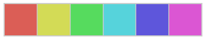

```python
import pandas as pd
import matplotlib.pyplot as plt
import matplotlib as mpl
%matplotlib inline
import seaborn as sns
import numpy as np
import statsmodels.api as sm
import scipy as sp

from sklearn import datasets, linear_model
from sklearn.metrics import mean_squared_error, r2_score


# setting seaborn figure aesthetics
sns.set(context='talk', style='whitegrid',font='sans-serif',font_scale=0.75, color_codes=True, rc={'figure.figsize':(11.7,8.27)})

# set colours
palette = sns.color_palette('hls')
sns.set_palette(palette)
sns.palplot(palette)

# assign continents to a colour in the palette
continent_colours = {'Europe':palette[0],'Oceania':palette[1], 'North America':palette[2], 'Asia':palette[3], 'South America':palette[4], 'Africa':palette[5]}

# setting pandas to show all rows and columns when acessing dataframe
pd.set_option('display.max_columns', None)
pd.set_option('display.max_rows', None)

# check what version of libraries are being used
print ('Pandas version:',pd.__version__)
print ('Seaborn version:',sns.__version__)
```

[Citation 1](https://seaborn.pydata.org/generated/seaborn.set_context.html), [itation 2](https://seaborn.pydata.org/tutorial/aesthetics.html)

- 1. Objectives
- 2. Data Aquisition & Inspection
  - 2.1 City Quality of Life
  - 2.2 Human Development Index
- 3. Data Preparation
  - 3.1 City Quality of Life
    - 3.1.1 Cleaning
    - 3.1.2 Missing Values
  - 3.2 Human Development Index
    - 3.2.1 Cleaning
    - 3.2.2 Missing Values
- 4. Feature Engineering
- 5. Modelling

## 1. Objectives

The objective of this project is to anser the question of "what makes a city liveable?". This will be answered through answering the following questions:

- what are the most important factors when predicting liveability?
- which countries have the best cities and how does it related to the HDI of that country?

## 2. Data Aquisitition & Inspection

### 2.1 City Quality of Life

Data was downloaded from kaggle's "[City Quality of Life](https://www.kaggle.com/orhankaramancode/city-quality-of-life-dataset)" dataset obtained from Teleport.org

```python
# import 'city quality of life' dataset
cityQOL = pd.read_csv('Data/City Quality of Life/uaScoresDataFrame.csv')
cityQOL.head()
```

|  | Unnamed: 0 | UA_Name | UA_Country | UA_Continent | Housing | Cost of Living | Startups | Venture Capital | Travel Connectivity | Commute | Business Freedom | Safety | Healthcare | Education | Environmental Quality | Economy | Taxation | Internet Access | Leisure & Culture | Tolerance | Outdoors |
| --- | --- | --- | --- | --- | --- | --- | --- | --- | --- | --- | --- | --- | --- | --- | --- | --- | --- | --- | --- | --- | --- |
| 0 | 0 | Aarhus | Denmark | Europe | 6.1315 | 4.015 | 2.8270 | 2.512 | 3.5360 | 6.31175 | 9.940000 | 9.6165 | 8.704333 | 5.3665 | 7.63300 | 4.8865 | 5.0680 | 8.373 | 3.1870 | 9.7385 | 4.1300 |
| 1 | 1 | Adelaide | Australia | Oceania | 6.3095 | 4.692 | 3.1365 | 2.640 | 1.7765 | 5.33625 | 9.399667 | 7.9260 | 7.936667 | 5.1420 | 8.33075 | 6.0695 | 4.5885 | 4.341 | 4.3285 | 7.8220 | 5.5310 |
| 2 | 2 | Albuquerque | New Mexico | North America | 7.2620 | 6.059 | 3.7720 | 1.493 | 1.4555 | 5.05575 | 8.671000 | 1.3435 | 6.430000 | 4.1520 | 7.31950 | 6.5145 | 4.3460 | 5.396 | 4.8900 | 7.0285 | 3.5155 |
| 3 | 3 | Almaty | Kazakhstan | Asia | 9.2820 | 9.333 | 2.4585 | 0.000 | 4.5920 | 5.87125 | 5.568000 | 7.3090 | 4.545667 | 2.2830 | 3.85675 | 5.2690 | 8.5220 | 2.886 | 2.9370 | 6.5395 | 5.5000 |
| 4 | 4 | Amsterdam | Netherlands | Europe | 3.0530 | 3.824 | 7.9715 | 6.107 | 8.3245 | 6.11850 | 8.836667 | 8.5035 | 7.907333 | 6.1800 | 7.59725 | 5.0530 | 4.9550 | 4.523 | 8.8740 | 8.3680 | 5.3070 |

```python
# Info about the dataset
print('Cities Dataframe has {} rows and {} columns'.format(cityQOL.shape[0], cityQOL.shape[1]))
cityQOL.describe()
```

```
Cities Dataframe has 266 rows and 21 columns
```

|  | Unnamed: 0 | Housing | Cost of Living | Startups | Venture Capital | Travel Connectivity | Commute | Business Freedom | Safety | Healthcare | Education | Environmental Quality | Economy | Taxation | Internet Access | Leisure & Culture | Tolerance | Outdoors |
| --- | --- | --- | --- | --- | --- | --- | --- | --- | --- | --- | --- | --- | --- | --- | --- | --- | --- | --- |
| count | 266.000000 | 266.000000 | 266.000000 | 266.000000 | 266.000000 | 266.000000 | 266.000000 | 266.000000 | 266.000000 | 266.000000 | 266.000000 | 266.000000 | 266.000000 | 266.000000 | 266.000000 | 266.000000 | 266.000000 | 266.000000 |
| mean | 132.500000 | 6.467271 | 5.745940 | 4.595295 | 2.702515 | 3.446966 | 4.631770 | 7.330762 | 6.971635 | 6.796580 | 3.835224 | 6.078278 | 5.058141 | 4.953195 | 5.205013 | 5.710068 | 6.792742 | 4.492840 |
| std | 76.931788 | 2.294482 | 2.447104 | 2.152841 | 2.553445 | 2.091628 | 1.523065 | 2.109427 | 1.746631 | 1.481896 | 2.213013 | 2.199913 | 1.517210 | 1.689790 | 1.872223 | 2.006776 | 1.724671 | 1.591771 |
| min | 0.000000 | 0.000000 | 0.000000 | 0.000000 | 0.000000 | 0.500000 | 0.000000 | 0.000000 | 1.343500 | 0.000000 | 0.000000 | 1.000000 | 0.000000 | 0.500000 | 1.000000 | 0.000000 | 1.406000 | 0.500000 |
| 25% | 66.250000 | 5.149500 | 4.795000 | 3.097500 | 0.000000 | 1.703250 | 4.399625 | 5.771417 | 5.972375 | 6.064083 | 2.184375 | 4.328688 | 4.103000 | 3.920500 | 4.134000 | 4.448125 | 5.779875 | 3.698625 |
| 50% | 132.500000 | 6.726000 | 5.630500 | 4.214000 | 2.317500 | 2.921500 | 5.064375 | 8.403667 | 7.188500 | 6.780500 | 4.273250 | 6.480750 | 5.373500 | 4.759750 | 5.378750 | 5.706750 | 7.154500 | 4.733000 |
| 75% | 198.750000 | 8.312750 | 7.595500 | 5.790375 | 3.764750 | 4.766000 | 5.613188 | 8.836667 | 8.269125 | 8.054500 | 5.294375 | 7.887625 | 6.514500 | 5.954500 | 6.265250 | 7.062500 | 8.052125 | 5.500000 |
| max | 265.000000 | 10.000000 | 10.000000 | 10.000000 | 10.000000 | 10.000000 | 6.728500 | 10.000000 | 10.000000 | 9.320667 | 9.711000 | 9.953250 | 9.390000 | 10.000000 | 9.716000 | 10.000000 | 9.738500 | 7.933000 |

```python
# find the number of countries represented in the dataset
print(cityQOL.UA_Country.unique())
```

```
[' Denmark' ' Australia' ' New Mexico' ' Kazakhstan' ' Netherlands'
 ' Alaska' 'Andorra' ' Turkey' ' North Carolina' ' Paraguay' ' Greece'
 ' Georgia' ' New Zealand' ' Texas' ' Azerbaijan' ' Indonesia' ' Maryland'
 ' Thailand' ' Spain' ' China' ' Lebanon' ' United Kingdom' ' Serbia'
 ' Belize' ' India' ' Norway' ' Germany' ' Switzerland' ' Alabama'
 ' Colombia' ' Idaho' ' Italy' ' France' ' Massachusetts' ' Colorado'
 ' Montana' ' Slovakia' ' Czechia' ' Belgium' ' Romania' ' Hungary'
 ' Argentina' ' New York' ' Egypt' ' Canada' ' South Africa' ' Venezuela'
 ' Morocco' ' South Carolina' ' Tennessee' ' Illinois' ' Moldova' ' Ohio'
 ' Ireland' ' Brazil' ' Tanzania' ' Iowa' ' Michigan' ' Qatar'
 ' United Arab Emirates' ' Oregon' ' Japan' ' Poland' ' Gibraltar'
 ' Sweden' ' Mexico' ' Guatemala' ' Cuba' ' Finland' ' Vietnam'
 ' Hong Kong' ' Hawaii' ' Indiana' ' Austria' ' Florida' ' Missouri'
 ' Nepal' ' Ukraine' ' Jamaica' ' Malaysia' ' Nigeria' ' Bolivia'
 ' Nevada' ' Peru' ' Portugal' ' Slovenia' ' California' ' Kentucky'
 ' Luxembourg' ' Wisconsin' ' Nicaragua' ' Philippines' ' Minnesota'
 ' Belarus' ' Uruguay' ' Russia' ' Kenya' ' Louisiana' ' Cyprus'
 ' Oklahoma' ' Nebraska' ' Panama' ' Pennsylvania' ' Cambodia' ' Arizona'
 ' Maine' ' Rhode Island' ' Ecuador' ' Iceland' ' Virginia' ' Latvia'
 ' Saudi Arabia' ' Utah' ' Costa Rica' ' Puerto Rico' ' El Salvador'
 ' Chile' ' Dominican Republic' ' Bosnia and Herzegovina' ' Washington'
 ' South Korea' ' Singapore' ' Macedonia' ' Bulgaria' ' Taiwan' ' Estonia'
 ' Uzbekistan' ' Iran' ' Israel' ' Tunisia' ' Malta' ' Lithuania'
 ' District of Columbia' ' Armenia' ' Croatia']
```

```python
# find what continents are represented in the dataset
print(cityQOL.UA_Continent.unique())
```

```
['Europe' 'Oceania' 'North America' 'Asia' 'South America' 'Africa']
```

```python
# find the number of cities represented in each country
#cityQOL['UA_Country'].value_counts()
```

```python
cityQOL['UA_Continent'].value_counts()
```

```
Europe           111
North America     87
Asia              37
South America     15
Africa             8
Oceania            8
Name: UA_Continent, dtype: int64
```

### 2.2 Human Development Index

Data taken from the UNITED NATIONS DEVELOPMENT PROGRAMME [Human Development Reports](http://hdr.undp.org/en/data)

```python
HDI = pd.read_csv('Data/HDI/Human_Development_Index.csv')
HDI.head()
```

|  | HDI Rank | Country | 1990 | Unnamed: 3 | 1991 | Unnamed: 5 | 1992 | Unnamed: 7 | 1993 | Unnamed: 9 | 1994 | Unnamed: 11 | 1995 | Unnamed: 13 | 1996 | Unnamed: 15 | 1997 | Unnamed: 17 | 1998 | Unnamed: 19 | 1999 | Unnamed: 21 | 2000 | Unnamed: 23 | 2001 | Unnamed: 25 | 2002 | Unnamed: 27 | 2003 | … |
| --- | --- | --- | --- | --- | --- | --- | --- | --- | --- | --- | --- | --- | --- | --- | --- | --- | --- | --- | --- | --- | --- | --- | --- | --- | --- | --- | --- | --- | --- | --- |
| 0 | 169 | Afghanistan | 0.302 | NaN | 0.307 | NaN | 0.316 | NaN | 0.312 | NaN | 0.307 | NaN | 0.331 | NaN | 0.335 | NaN | 0.339 | NaN | 0.344 | NaN | 0.348 | NaN | 0.35 | NaN | 0.353 | NaN | 0.384 | NaN | 0.393 | … |
| 1 | 69 | Albania | 0.65 | NaN | 0.631 | NaN | 0.615 | NaN | 0.618 | NaN | 0.624 | NaN | 0.637 | NaN | 0.646 | NaN | 0.645 | NaN | 0.655 | NaN | 0.665 | NaN | 0.671 | NaN | 0.678 | NaN | 0.684 | NaN | 0.691 | … |
| 2 | 91 | Algeria | 0.572 | NaN | 0.576 | NaN | 0.582 | NaN | 0.586 | NaN | 0.59 | NaN | 0.595 | NaN | 0.602 | NaN | 0.611 | NaN | 0.621 | NaN | 0.629 | NaN | 0.637 | NaN | 0.647 | NaN | 0.657 | NaN | 0.667 | … |
| 3 | 36 | Andorra | .. | NaN | .. | NaN | .. | NaN | .. | NaN | .. | NaN | .. | NaN | .. | NaN | .. | NaN | .. | NaN | .. | NaN | 0.813 | NaN | 0.815 | NaN | 0.82 | NaN | 0.827 | … |
| 4 | 148 | Angola | .. | NaN | .. | NaN | .. | NaN | .. | NaN | .. | NaN | .. | NaN | .. | NaN | .. | NaN | .. | NaN | 0.391 | NaN | 0.4 | NaN | 0.41 | NaN | 0.426 | NaN | 0.435 | … |

```python
# Info about the dataset
#print('HDI Dataframe has {} rows and {} columns'.format(HDI.shape[0], HDI.shape[1]))
#HDI.describe()
```

```python
# find the number of countries represented in the dataset
print(HDI.Country.unique())
```

```
[' Afghanistan' ' Albania' ' Algeria' ' Andorra' ' Angola'
 ' Antigua and Barbuda' ' Argentina' ' Armenia' ' Australia' ' Austria'
 ' Azerbaijan' ' Bahamas' ' Bahrain' ' Bangladesh' ' Barbados' ' Belarus'
 ' Belgium' ' Belize' ' Benin' ' Bhutan' ' Bolivia'
 ' Bosnia and Herzegovina' ' Botswana' ' Brazil' ' Brunei Darussalam'
 ' Bulgaria' ' Burkina Faso' ' Burundi' ' Cabo Verde' ' Cambodia'
 ' Cameroon' ' Canada' ' Central African Republic' ' Chad' ' Chile'
 ' China' ' Colombia' ' Comoros' ' Congo' ' Costa Rica' ' Croatia' ' Cuba'
 ' Cyprus' ' Czechia' " Côte d'Ivoire" ' Denmark' ' Djibouti' ' Dominica'
 ' Dominican Republic' ' Ecuador' ' Egypt' ' El Salvador'
 ' Equatorial Guinea' ' Eritrea' ' Estonia' ' Eswatini' ' Ethiopia'
 ' Fiji' ' Finland' ' France' ' Gabon' ' Gambia' ' Georgia' ' Germany'
 ' Ghana' ' Greece' ' Grenada' ' Guatemala' ' Guinea' ' Guinea-Bissau'
 ' Guyana' ' Haiti' ' Honduras' ' Hong Kong' ' Hungary' ' Iceland'
 ' India' ' Indonesia' ' Iran' ' Iraq' ' Ireland' ' Israel' ' Italy'
 ' Jamaica' ' Japan' ' Jordan' ' Kazakhstan' ' Kenya' ' Kiribati'
 ' South Korea' ' Kuwait' ' Kyrgyzstan'
 " Lao People's Democratic Republic" ' Latvia' ' Lebanon' ' Lesotho'
 ' Liberia' ' Libya' ' Liechtenstein' ' Lithuania' ' Luxembourg'
 ' Madagascar' ' Malawi' ' Malaysia' ' Maldives' ' Mali' ' Malta'
 ' Marshall Islands' ' Mauritania' ' Mauritius' ' Mexico' ' Micronesia'
 ' Moldova' ' Mongolia' ' Montenegro' ' Morocco' ' Mozambique' ' Myanmar'
 ' Namibia' ' Nepal' ' Netherlands' ' New Zealand' ' Nicaragua' ' Niger'
 ' Nigeria' ' North Macedonia' ' Norway' ' Oman' ' Pakistan' ' Palau'
 ' Palestine' ' Panama' ' Papua New Guinea' ' Paraguay' ' Peru'
 ' Philippines' ' Poland' ' Portugal' ' Qatar' ' Romania' ' Russia'
 ' Rwanda' ' Saint Kitts and Nevis' ' Saint Lucia'
 ' Saint Vincent and the Grenadines' ' Samoa' ' Sao Tome and Principe'
 ' Saudi Arabia' ' Senegal' ' Serbia' ' Seychelles' ' Sierra Leone'
 ' Singapore' ' Slovakia' ' Slovenia' ' Solomon Islands' ' South Africa'
 ' South Sudan' ' Spain' ' Sri Lanka' ' Sudan' ' Suriname' ' Sweden'
 ' Switzerland' ' Syrian Arab Republic' ' Tajikistan' ' Tanzania'
 ' Thailand' ' Timor-Leste' ' Togo' ' Tonga' ' Trinidad and Tobago'
 ' Tunisia' ' Turkey' ' Turkmenistan' ' Uganda' ' Ukraine'
 ' United Arab Emirates' ' United Kingdom' 'USA' ' Uruguay' ' Uzbekistan'
 ' Vanuatu' ' Venezuela' ' Vietnam' ' Yemen' ' Zambia' ' Zimbabwe'
 'Human Development' 'Very high human development'
 'High human development' 'Medium human development'
 'Low human development' 'Developing Countries' 'Regions' 'Arab States'
 'East Asia and the Pacific' 'Europe and Central Asia'
 'Latin America and the Caribbean' 'South Asia' 'Sub-Saharan Africa'
 'Least Developed Countries' 'Small Island Developing States'
 'Organization for Economic Co-operation and Development' 'World']
```

```python
# check for random spaces by pulling a random country
HDI['Country'][1]
```

```
' Albania'
```

**NOTES:** There are empty unnamed columns that need to be removed. Also, certain rows are should not exist for example "high human development" in the country column. Only the most recent HDI from 2019 will be kept. There is also a second dataset conserning regions and continents that is joined to this one that needs to be spearated out. There are spaces infront of some country names

## 3. Data Preparation

### 3.1 City Quality of Life

#### 3.1.1 Cleaning

```python
# delete the unnamed column
cityQOL.drop('Unnamed: 0', inplace = True, axis=1)
```

```python
# rename first 3 columns
cityQOL = cityQOL.rename(columns={"UA_Name": "City", "UA_Country": "Country", "UA_Continent":"Continent"})

# get rid of white space infront of countries
for i in range(0,len(cityQOL['Country'])):
    cityQOL.loc[i,'Country'] = cityQOL.loc[i,'Country'].strip()
```

```python
# get rid of American states accidentally in the "Country" column
states =['Alabama','Alaska','Arizona','Arkansas','California','Colorado','Connecticut','Delaware','Florida','Georgia','Hawaii','Idaho','Illinois','Indiana','Iowa','Kansas','Kentucky','Louisiana','Maine','Maryland','Massachusetts','Michigan','Minnesota','Mississippi','Missouri','Montana','Nebraska','Nevada','New Hampshire','New Jersey','New Mexico','New York','North Carolina','North Dakota','Ohio','Oklahoma','Oregon','Pennsylvania','Rhode Island','South Carolina','South Dakota','Tennessee','Texas','Utah','Vermont','Virginia','Washington','West Virginia','Wisconsin','Wyoming']

for j in states:
    cityQOL['Country'].where(cityQOL['Country']!= j, inplace=True, other='USA')

# inspect how the dataset looks
#cityQOL
```

#### 3.2 Missing Values

```python
# check for missing values in each column of the data frame
cityQOL.isnull().sum()
```

```
City                     0
Country                  0
Continent                0
Housing                  0
Cost of Living           0
Startups                 0
Venture Capital          0
Travel Connectivity      0
Commute                  0
Business Freedom         0
Safety                   0
Healthcare               0
Education                0
Environmental Quality    0
Economy                  0
Taxation                 0
Internet Access          0
Leisure & Culture        0
Tolerance                0
Outdoors                 0
dtype: int64
```

**NOTES:** it seems that the are no missing values present. 0's present in the dataset are purposeful, indicating a score of 0/10 in a particular category.

### 3.2 Human Development Index

#### 3.2.1 Cleaning

```python
# remove unnecessary columns
HDI = HDI[['HDI Rank', 'Country','2019']]

# get rid of white space infront of countries
for i in range(0,len(HDI['Country'])):
    HDI.loc[i,'Country'] = HDI.loc[i,'Country'].strip()

# create regional HDI dataframe
HDI_regional = HDI[195:205]

# drop regional indicators andother unnecesary rows from the HDI country dataframe
HDI = HDI[0:189]
```

```python
# remove countries that are not represented in both datasets
countries = list(cityQOL['Country'].unique())
HDI = HDI[HDI['Country'].isin(countries)]

# sort list by HDI rank
HDI = HDI.sort_values('2019', axis=0, ascending=False)

#re-index HDI dataframe
HDI.reset_index(drop=True, inplace=True)

# rename column "2019" to "HDI"
HDI= HDI.rename(columns={"2019": "HDI"})
```

#### 3.2.2 Missing Values

```python
# check for missing values in each column of the data frame
HDI.isnull().sum()
```

```
HDI Rank    0
Country     0
HDI         0
dtype: int64
```

## 4. Feature Engineering

- Create a 'Overall Score' out of 100 for the city by adding all the points in each category together, dividing by the total number of points available(170), and multiplying by 100:</br>
  - $ Overall Score = \frac{Housing+Cost\ of\ Living+ Startups+Venture\ Capital+Travel\ Connectivity+ Commute+ Business\ Freedom+ Safety+Healthcare+Education+Environmental\ Quality+Economy+Taxation+Internet\ Access+Leisure\ and\ Culture+ Tolerance +Outdoors}{170}x 100 $</br>
- Create average scores per country

```python
# calculate city's overall score
cityQOL['Score']=((cityQOL.sum(axis=1))/170)*100
cityQOL.head()
```

|  | City | Country | Continent | Housing | Cost of Living | Startups | Venture Capital | Travel Connectivity | Commute | Business Freedom | Safety | Healthcare | Education | Environmental Quality | Economy | Taxation | Internet Access | Leisure & Culture | Tolerance | Outdoors | Score |
| --- | --- | --- | --- | --- | --- | --- | --- | --- | --- | --- | --- | --- | --- | --- | --- | --- | --- | --- | --- | --- | --- |
| 0 | Aarhus | Denmark | Europe | 6.1315 | 4.015 | 2.8270 | 2.512 | 3.5360 | 6.31175 | 9.940000 | 9.6165 | 8.704333 | 5.3665 | 7.63300 | 4.8865 | 5.0680 | 8.373 | 3.1870 | 9.7385 | 4.1300 | 59.986225 |
| 1 | Adelaide | Australia | Oceania | 6.3095 | 4.692 | 3.1365 | 2.640 | 1.7765 | 5.33625 | 9.399667 | 7.9260 | 7.936667 | 5.1420 | 8.33075 | 6.0695 | 4.5885 | 4.341 | 4.3285 | 7.8220 | 5.5310 | 56.062549 |
| 2 | Albuquerque | USA | North America | 7.2620 | 6.059 | 3.7720 | 1.493 | 1.4555 | 5.05575 | 8.671000 | 1.3435 | 6.430000 | 4.1520 | 7.31950 | 6.5145 | 4.3460 | 5.396 | 4.8900 | 7.0285 | 3.5155 | 49.825735 |
| 3 | Almaty | Kazakhstan | Asia | 9.2820 | 9.333 | 2.4585 | 0.000 | 4.5920 | 5.87125 | 5.568000 | 7.3090 | 4.545667 | 2.2830 | 3.85675 | 5.2690 | 8.5220 | 2.886 | 2.9370 | 6.5395 | 5.5000 | 51.030980 |
| 4 | Amsterdam | Netherlands | Europe | 3.0530 | 3.824 | 7.9715 | 6.107 | 8.3245 | 6.11850 | 8.836667 | 8.5035 | 7.907333 | 6.1800 | 7.59725 | 5.0530 | 4.9550 | 4.523 | 8.8740 | 8.3680 | 5.3070 | 65.590147 |

```python
# create tables for each continent
continents = cityQOL.groupby(cityQOL.Continent)
europe = continents.get_group("Europe")
oceania = continents.get_group("Oceania")
north_america = continents.get_group("North America")
asia = continents.get_group("Asia")
south_america = continents.get_group("South America")
africa = continents.get_group("Africa")
```

```python
# Calculate average scores per country
countries = cityQOL['Country'].unique().tolist()

# create dataframe for countries
countriesQOL = []

for country in countries:
    to_append = cityQOL[cityQOL['Country'] == country].mean(axis=0).tolist()
    to_append.insert(0,country)
    countriesQOL.append(to_append)

countries_df = pd.DataFrame(countriesQOL)

# rename columns
countriesQOL = countries_df.rename(columns={0: "Country", 1: "Housing", 2: "Cost of Living", 3:"Startups", 4:"Venture Capital", 5:"Travel Connectivity", 6:"Commute", 7:"Business Freedom", 8:"Safety", 9:"Healthcare", 10:"Education",11:"Environmental Quality", 12:"Economy", 13:"Taxation",14:"Internet Access",15:"Leisure & Culture", 16:"Tolerance", 17:"Outdoors",18:"Average City Score"})
```

```python
# add HDI to countriesQOL
HDI_merge = HDI.iloc[:,1:3]
countriesQOL = countriesQOL.set_index('Country').join(HDI_merge.set_index('Country'), lsuffix='HDI')

# fix the index and country column
countriesQOL.reset_index(drop=False, inplace=True)

# drop countries with NaN HDI
countriesQOL= countriesQOL.dropna()
```

```python
# Add a continents column to the countriesQOL dataframe
countriesQOL.insert(loc=1, column='Continent', value=['' for i in range(countriesQOL.shape[0])])
```

```python
# create lists of the countries in each continent
eur_countries = europe['Country'].unique().tolist()
africa_countries = africa['Country'].unique().tolist()
oceania_countries = oceania['Country'].unique().tolist()
na_countries = north_america['Country'].unique().tolist()
asia_countries = asia['Country'].unique().tolist()
sa_countries = south_america['Country'].unique().tolist()

# identify European countries
for i in eur_countries:
    countriesQOL['Continent'].mask(countriesQOL['Country']==i, other='Europe', inplace=True)

# identify African countries
for i in africa_countries:
    countriesQOL['Continent'].mask(countriesQOL['Country']==i, other='Africa', inplace=True)

# identify Oceanian countries
for i in oceania_countries:
    countriesQOL['Continent'].mask(countriesQOL['Country']==i, other='Oceania', inplace=True)

# identify North American countries
for i in na_countries:
    countriesQOL['Continent'].mask(countriesQOL['Country']==i, other='North America', inplace=True)

# identify Asian countries
for i in asia_countries:
    countriesQOL['Continent'].mask(countriesQOL['Country']==i, other='Asia', inplace=True)

# identify South American countries
for i in sa_countries:
    countriesQOL['Continent'].mask(countriesQOL['Country']==i, other='South America', inplace=True)
```

```python
countriesQOL['HDI'] = pd.to_numeric(countriesQOL['HDI'])
countriesQOL.head()
```

|  | Country | Continent | Housing | Cost of Living | Startups | Venture Capital | Travel Connectivity | Commute | Business Freedom | Safety | Healthcare | Education | Environmental Quality | Economy | Taxation | Internet Access | Leisure & Culture | Tolerance | Outdoors | Average City Score | HDI |
| --- | --- | --- | --- | --- | --- | --- | --- | --- | --- | --- | --- | --- | --- | --- | --- | --- | --- | --- | --- | --- | --- |
| 0 | Denmark | Europe | 5.179250 | 3.720500 | 4.517000 | 3.489500 | 4.918000 | 6.303625 | 9.940000 | 9.384500 | 8.344833 | 5.333750 | 7.952625 | 4.8865 | 5.068000 | 7.806250 | 5.125000 | 9.417000 | 4.400500 | 62.227549 | 0.940 |
| 1 | Australia | Oceania | 4.714200 | 4.718000 | 6.307400 | 4.085800 | 2.490600 | 4.874400 | 9.399667 | 7.527500 | 8.072667 | 5.830400 | 8.199850 | 6.0695 | 4.588500 | 4.711900 | 5.107700 | 7.363000 | 5.987500 | 58.852108 | 0.944 |
| 2 | USA | North America | 5.134577 | 4.855969 | 5.603062 | 3.677677 | 2.447223 | 3.753150 | 8.608338 | 5.018469 | 6.306072 | 4.660777 | 7.004004 | 6.4797 | 4.352831 | 6.201031 | 5.850523 | 6.716323 | 4.463431 | 53.607739 | 0.926 |
| 3 | Kazakhstan | Asia | 9.282000 | 9.333000 | 2.458500 | 0.000000 | 4.592000 | 5.871250 | 5.568000 | 7.309000 | 4.545667 | 2.283000 | 3.856750 | 5.2690 | 8.522000 | 2.886000 | 2.937000 | 6.539500 | 5.500000 | 51.030980 | 0.825 |
| 4 | Netherlands | Europe | 5.373700 | 4.628000 | 4.744300 | 2.998000 | 7.477100 | 5.833700 | 8.836667 | 8.659700 | 8.280733 | 5.093000 | 7.973650 | 5.0530 | 4.955000 | 6.244800 | 5.804500 | 8.621900 | 4.767300 | 61.967676 | 0.944 |

## 5. Modelling

### 5.1 Initial Data Visualisation

#### 5.1.1 City Liveability

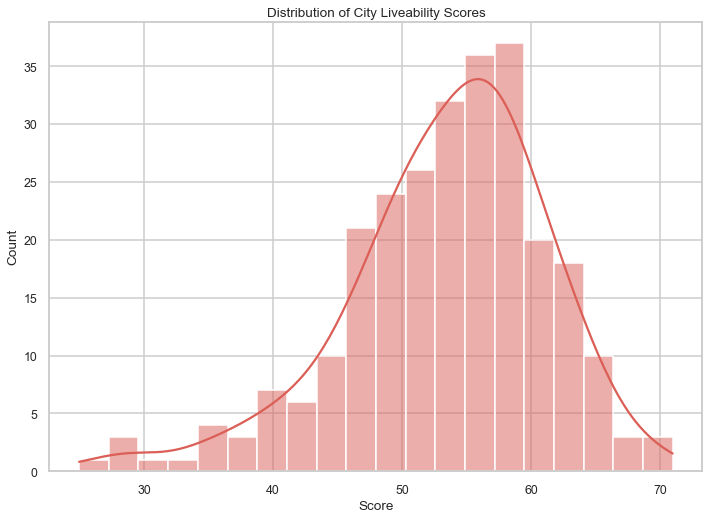

```python
# distribution of city liveability scores
sns.histplot(data=cityQOL, x='Score',bins=20, discrete=False, kde=True);
plt.title('Distribution of City Liveability Scores');
```

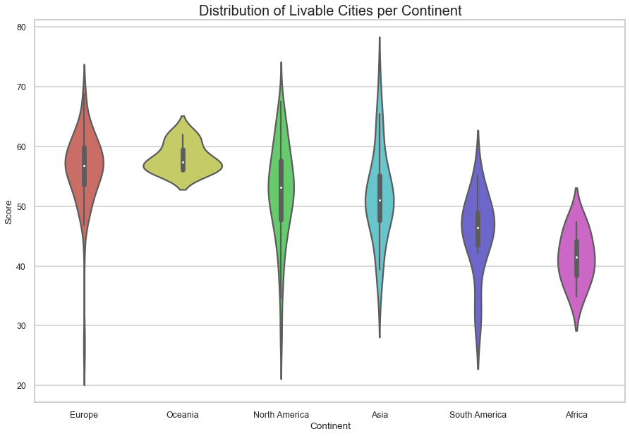

```python
# violin plot
f, ax = plt.subplots(figsize=(15, 10))
sns.violinplot(x='Continent', y='Score',data=cityQOL);
plt.title('Distribution of Livable Cities per Continent', fontsize=20 );
```

[Citation](https://seaborn.pydata.org/generated/seaborn.violinplot.html#seaborn.violinplot)

#### 5.1.2 National Liveability

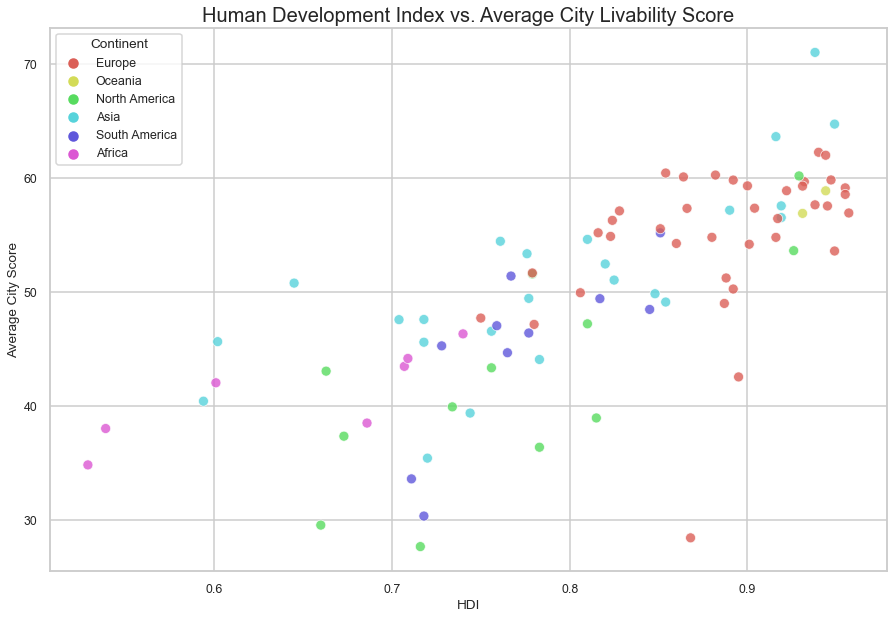

```python
f, ax = plt.subplots(figsize=(15, 10))
sns.scatterplot(data=countriesQOL, y="Average City Score", x="HDI", hue="Continent",s=100,alpha=0.8);
plt.title('Human Development Index vs. Average City Livability Score', fontsize=20);
```

### 5.2 Predictors of City Livability

#### Correlation Matrix

Correlation between the predictors of the CityQOL dataframe

```
Score                    1.000000
Education                0.779021
Business Freedom         0.683916
Healthcare               0.586328
Commute                  0.568402
Venture Capital          0.557986
Travel Connectivity      0.550047
Internet Access          0.533535
Environmental Quality    0.526576
Startups                 0.517422
Name: Score, dtype: float64
```

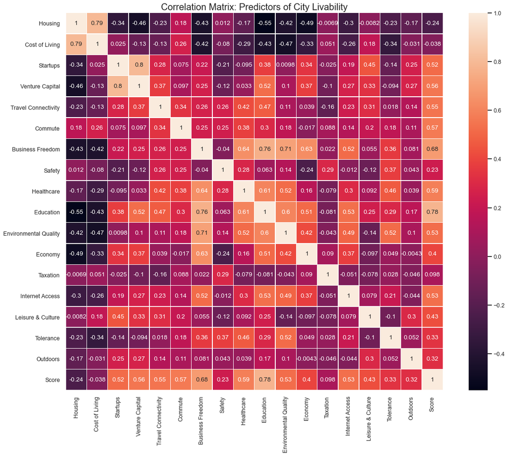

```python
# Compute the correlation
corr = cityQOL.corr()

# print top 10 correlations with city score
print (corr['Score'].sort_values(ascending=False)[:10], '\n')

# plot correlation matrix
fig, ax = plt.subplots(figsize=(20,15))
sns.heatmap(corr, annot=True, linewidths=.5, square=True, ax=ax);
plt.title("Correlation Matrix: Predictors of City Livability", fontsize=20);
```

#### Multiple Regression

```python
# dependent variable
dependent = cityQOL['Score'];

# independent variables
independents = cityQOL[["Housing",'Cost of Living','Startups',
                        'Venture Capital','Travel Connectivity',
                        'Commute','Business Freedom','Safety',
                        'Healthcare','Education','Environmental Quality',
                        'Economy','Taxation','Internet Access',
                        'Leisure & Culture','Tolerance','Outdoors']]

# We have to manually add the intercepts
independents_withconst = sm.add_constant(independents)

# we use the OLS function from statsmodels
model = sm.OLS(dependent,independents_withconst)
results = model.fit()

print (results.summary())
```

```
                            OLS Regression Results
==============================================================================
Dep. Variable:                  Score   R-squared:                       1.000
Model:                            OLS   Adj. R-squared:                  1.000
Method:                 Least Squares   F-statistic:                 2.399e+30
Date:                Sun, 20 Dec 2020   Prob (F-statistic):               0.00
Time:                        13:36:43   Log-Likelihood:                 8024.5
No. Observations:                 266   AIC:                        -1.601e+04
Df Residuals:                     248   BIC:                        -1.595e+04
Df Model:                          17
Covariance Type:            nonrobust
=========================================================================================
                            coef    std err          t      P>|t|      [0.025      0.975]
-----------------------------------------------------------------------------------------
const                          0   1.41e-14          0      1.000   -2.78e-14    2.78e-14
Housing                   0.5882   1.23e-15    4.8e+14      0.000       0.588       0.588
Cost of Living            0.5882   1.07e-15    5.5e+14      0.000       0.588       0.588
Startups                  0.5882    1.1e-15   5.33e+14      0.000       0.588       0.588
Venture Capital           0.5882   9.48e-16    6.2e+14      0.000       0.588       0.588
Travel Connectivity       0.5882   8.35e-16   7.04e+14      0.000       0.588       0.588
Commute                   0.5882   1.05e-15    5.6e+14      0.000       0.588       0.588
Business Freedom          0.5882   1.35e-15   4.35e+14      0.000       0.588       0.588
Safety                    0.5882   9.85e-16   5.97e+14      0.000       0.588       0.588
Healthcare                0.5882   1.48e-15   3.97e+14      0.000       0.588       0.588
Education                 0.5882   1.23e-15   4.77e+14      0.000       0.588       0.588
Environmental Quality     0.5882   9.66e-16   6.09e+14      0.000       0.588       0.588
Economy                   0.5882   1.32e-15   4.46e+14      0.000       0.588       0.588
Taxation                  0.5882   8.59e-16   6.85e+14      0.000       0.588       0.588
Internet Access           0.5882   8.29e-16   7.09e+14      0.000       0.588       0.588
Leisure & Culture         0.5882    8.2e-16   7.18e+14      0.000       0.588       0.588
Tolerance                 0.5882   9.69e-16   6.07e+14      0.000       0.588       0.588
Outdoors                  0.5882   8.57e-16   6.86e+14      0.000       0.588       0.588
==============================================================================
Omnibus:                        5.615   Durbin-Watson:                   0.570
Prob(Omnibus):                  0.060   Jarque-Bera (JB):                5.783
Skew:                          -0.248   Prob(JB):                       0.0555
Kurtosis:                       3.525   Cond. No.                         266.
==============================================================================

Warnings:
[1] Standard Errors assume that the covariance matrix of the errors is correctly specified.
```

```python
results.predict()
```

```
array([59.98622549, 56.06254902, 49.82573529, 51.03098039, 65.59014706,
       47.58151961, 28.44911765, 49.77627451, 47.68504902, 45.26740196,
       52.11470588, 58.33843137, 57.15745098, 60.08583333, 46.55053922,
       40.04269608, 43.81230392, 54.72504902, 62.05279412, 55.26436275,
       39.38063725, 56.08019608, 49.92196078, 27.68205882, 50.59882353,
       53.83397059, 68.02264706, 54.93357843, 54.44357843, 55.53392157,
       44.44838235, 51.97137255, 52.22372549, 50.95916667, 51.76612745,
       65.50279412, 60.85093137, 43.65352941, 54.2377451 , 57.36063725,
       58.95019608, 58.42686275, 55.99343137, 59.26357843, 57.4375    ,
       60.40941176, 48.45872549, 53.56063725, 43.47171569, 61.70607843,
       58.77014706, 47.43794118, 33.61416667, 58.94931373, 38.50519608,
       50.94495098, 53.07651961, 49.24676471, 50.0845098 , 49.34093137,
       62.86897059, 47.70357843, 55.93034314, 53.89264706, 52.84818627,
       56.74073529, 59.27828431, 53.22985294, 55.92338235, 64.46887255,
       57.18735294, 45.90794118, 57.7695098 , 34.83872549, 51.11965686,
       59.4079902 , 53.19470588, 52.47151961, 49.83470588, 58.26485294,
       57.15205882, 61.88544118, 58.08558824, 62.50813725, 57.50147059,
       61.84308824, 51.80392157, 49.13857843, 42.06102941, 47.66867647,
       58.99098039, 51.45009804, 56.53803922, 53.52205882, 60.02985294,
       24.97019608, 57.35269608, 56.56392157, 48.91946078, 49.6929902 ,
       43.05186275, 56.97318627, 59.93166667, 56.16147059, 36.38632353,
       61.95740196, 47.56455882, 64.69607843, 50.59455882, 56.45926471,
       50.26343137, 53.47563725, 53.07098039, 55.10754902, 49.94411765,
       51.12965686, 40.89112745, 52.05333333, 55.97431373, 45.63754902,
       53.13710784, 39.92303922, 46.14583333, 55.92107843, 54.59730392,
       50.25754902, 38.02676471, 30.35764706, 53.18823529, 54.1904902 ,
       58.48382353, 58.17318627, 56.19098039, 49.9429902 , 46.39387255,
       61.79132353, 63.0552451 , 56.41960784, 68.8625    , 62.97852941,
       47.73063725, 54.7725    , 50.17137255, 58.17558824, 56.46779412,
       58.78455882, 57.30401961, 56.40720588, 29.56382353, 58.90617647,
       47.57911765, 53.73014706, 50.79563725, 62.02892157, 45.55857843,
       53.44573529, 55.20161765, 54.7122549 , 51.75460784, 59.08352941,
       54.85808824, 49.40264706, 66.45617647, 57.4495098 , 51.76313725,
       68.83004902, 42.03348039, 53.58583333, 46.74264706, 53.38264706,
       46.92176471, 65.09137255, 55.15441176, 48.9829902 , 52.19186275,
       50.38867647, 52.75769608, 58.84838235, 59.98313725, 63.46754902,
       51.36308824, 61.48264706, 50.1725    , 38.95044118, 64.56132353,
       56.11970588, 55.6127451 , 40.42102941, 55.78004902, 44.21784314,
       57.35436275, 40.52377451, 58.23362745, 58.34210784, 42.46161765,
       62.57671569, 46.31588235, 59.74754902, 47.03362745, 60.35196078,
       53.5775    , 51.44416667, 57.31357843, 44.6104902 , 49.10686275,
       49.46705882, 52.1697549 , 60.62495098, 55.07779412, 60.47593137,
       55.23191176, 62.9777451 , 64.08397059, 47.19813725, 34.70740196,
       45.68269608, 37.35397059, 55.16617647, 43.34426471, 48.28794118,
       47.14735294, 50.25941176, 60.55333333, 63.59784314, 55.93661765,
       53.59906863, 70.97578431, 50.06838235, 55.17367647, 57.40455882,
       62.85563725, 58.09303922, 61.09916667, 62.17485294, 62.71921569,
       54.56617647, 57.83411765, 56.86696078, 35.43098039, 53.98156863,
       44.07294118, 57.53264706, 60.10671569, 50.31382353, 65.46926471,
       67.57715686, 51.68666667, 46.31857843, 47.76328431, 59.33446078,
       54.26686275, 61.67348039, 59.59122549, 42.54602941, 64.71892157,
       59.66573529, 64.64691176, 60.23176471, 57.78647059, 56.85602941,
       57.53078431, 53.6320098 , 51.87862745, 53.33926471, 55.52813725,
       62.98578431])
```

#### Visualise Results

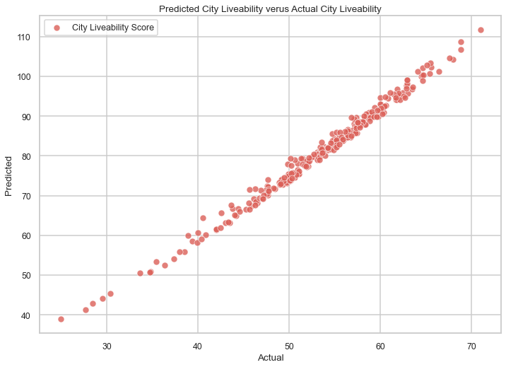

```python
# plot actual vs. predicted values
sns.scatterplot(dependent, results.predict(cityQOL.loc[:,'Housing':'Score']),label='City Liveability Score', alpha=0.8)
plt.title('Predicted City Liveability verus Actual City Liveability');
plt.xlabel('Actual');
plt.ylabel('Predicted');
plt.legend();
```

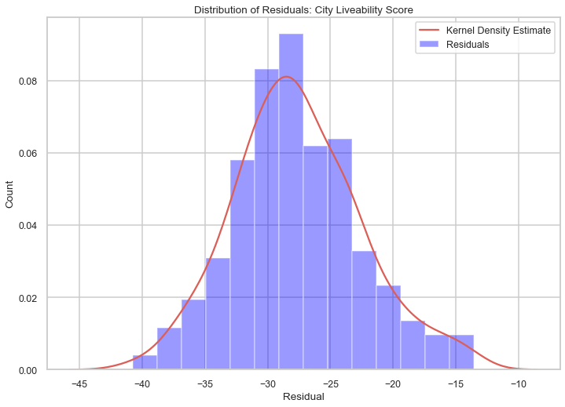

```python
# validate by residuals
sns.distplot(dependent-results.predict(cityQOL.loc[:,'Housing':'Score']),
             hist_kws={'color':'blue', 'label':'Residuals'},
             kde_kws={'label':'Kernel Density Estimate'})
plt.xlabel('Residual')
plt.ylabel('Count')
plt.title('Distribution of Residuals: City Liveability Score')
plt.legend()
```

### 5.3 Country Liveability and Human Development

#### Linear Regression Modelling

```python
# build a linear regression model to predict avg. city score from HDI
model = linear_model.LinearRegression()

# fit the model
model.fit(countriesQOL[['HDI']],countriesQOL['Average City Score'])
print('intercept: ', model.intercept_)
print('slope: ', model.coef_)

# find variation in average city score due to HDI
r_sq = model.score(countriesQOL[['HDI']],countriesQOL['Average City Score'])
print("R2 =",r_sq)
```

```
intercept:  -1.7465049534003683
slope:  [63.74791307]
R2 = 0.5536730198613458
```

**Predict the average city score from the HDI**:

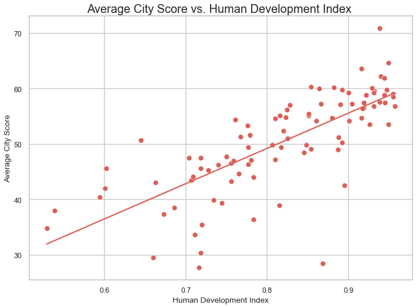

```python
# predictions
countriesQOL['pred'] = model.predict(countriesQOL[['HDI']])

# plot pred average city score and the actual average city score vs HDI
sns.lineplot(data = countriesQOL, x='HDI', y='pred');
sns.scatterplot(data=countriesQOL, x='HDI', y='Average City Score');
plt.title('Average City Score vs. Human Development Index ', fontsize=20);
plt.ylabel('Average City Score');
plt.xlabel('Human Development Index');
```

**Validation:**

```python
countriesQOL['resid'] = countriesQOL['pred'] - countriesQOL['Average City Score']
```

```
Mean 0.000000000000
Standard devation 5.915839542057
Mean city score 50.343080098817
Median city score 51.383504901961
```

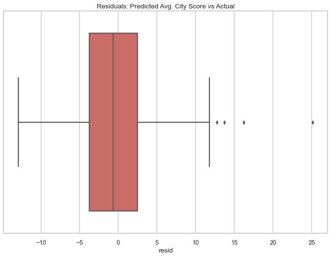

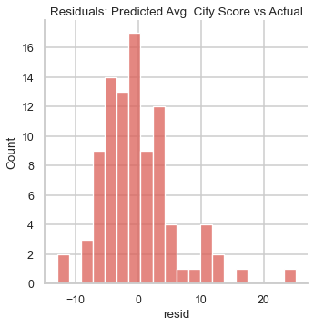

```python
# boxplot
sns.boxplot(countriesQOL['resid'])
plt.title('Residuals: Predicted Avg. City Score vs Actual')

# histogram
sns.displot(data=countriesQOL, x='resid',bins=20)
plt.title('Residuals: Predicted Avg. City Score vs Actual')

# stats
countriesQOL['resid'].describe()
print("Mean {:.12f}".format(countriesQOL['resid'].mean()))
print("Standard devation {:.12f}".format(countriesQOL['resid'].std()))
print("Mean city score {:.12f}".format(countriesQOL['Average City Score'].mean()))
print("Median city score {:.12f}".format(countriesQOL['Average City Score'].median()))
```

[citation](https://moodle.city.ac.uk/mod/page/view.php?id=1636316)

**Find correlation between average city score of a country and predictors:**

```python
# Compute the correlation
corr_countriesQOL = countriesQOL.corr()

# print top 10 correlations with city score
print (corr_countriesQOL['Average City Score'].sort_values(ascending=False)[:10], '\n')
```

```
Average City Score       1.000000
Education                0.813511
Business Freedom         0.778230
pred                     0.744092
HDI                      0.744092
Commute                  0.697246
Internet Access          0.674544
Environmental Quality    0.665081
Healthcare               0.625906
Travel Connectivity      0.592496
Name: Average City Score, dtype: float64
```